# Project Proposal

Zhenqi Zhou Last compiled date: 19 October, 2021

# Detecting the pedestrian shed and walking route environment of urban parks with open-source data

# Problem / Question

The propensity for visiting urban parks is affected by the park’s attractiveness and travel convenience, where walking provides the most basic and fair access. Walking routes from residences to parks, in terms of duration and perception, have received insufficient attention in the literature. Using the case study of Xuanwu Lake Park in China, I acquired walking routes from residences to the park through open-source data scraping in order to depict the pedestrian shed and pedestrian environment reasonably along these routes.

# Inspiring Examples

## Example 1

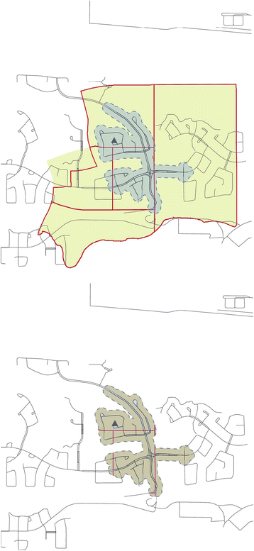

A reasonable walking distance is necessary for daily park users. There are many measurement to define pedestrian shed, such as Euclidean distance buffer method. This image proposed a line-based network buffer method that defined areas near the center line of routes as accessible, which is more accurate, as it is closer to the actual environment available to pedestrians.

## Example 2

[figure not shown]

This two images proposed several factors related to the pedestrian shed and walking route environment, which I can use.

## Example 3

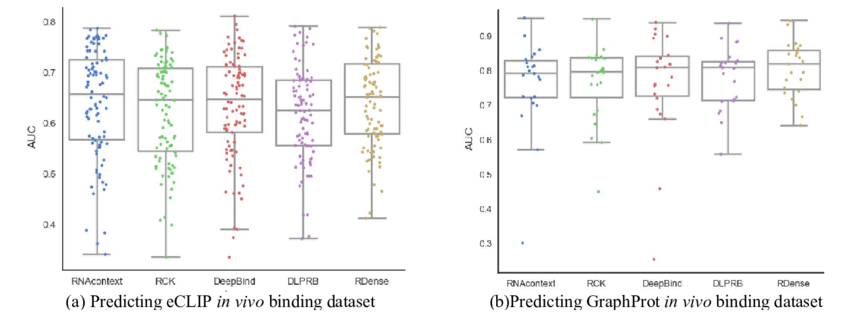

This is a scatter plot and box plot overlay for in vivo binding prediction. This kind of graph is easy to understand and rich with details. You can see the distribution of the data very clearly.

# Proposed data sources

I collected data from my own previous research projects. I uploaded my data to Github. Here is the link: https://github.com/GEO511-2021/2021_case_studies-ryan-zhenqi-zhou/tree/master/Final%20Project/Final%20Project%20Data%20Set

1. Residential building points of interest (Point)
2. Park entrances (Point)
3. Residential areas of interest (Polygon), which includes the information of population, POI density, green visual ratio and image elements.
4. Walking routes (Line): According to the policy of the 15-Minute Community-Life Circle, a 15-min walk to parks is important for residents in China, which corresponds to about a 1000-m distance. I called the travel navigation function of online map to scrape recommended walking routes from residential buildings to the entrances of Xuanwu Lake Park, with a 15-min duration as the threshold. This data also includes the information of route distance, duration, starting, and ending points.

Note that All data type is shapefile.

# Proposed methods

The park’s pedestrian shed was delineated by walking routes presumably reached within 15 min. By virtue of these walking routes, I developed 10 indices which related to the walking routes to the park. The former covers three indices of the service capacity: service POIs, service area, and service population, while the latter covers seven indices of the pedestrian environment: route distance, pedestrian route directness (PRD), the number of turns, the number of crossings, POI density along the route, green visual ratio, and image elements of street view photo (Table 1).

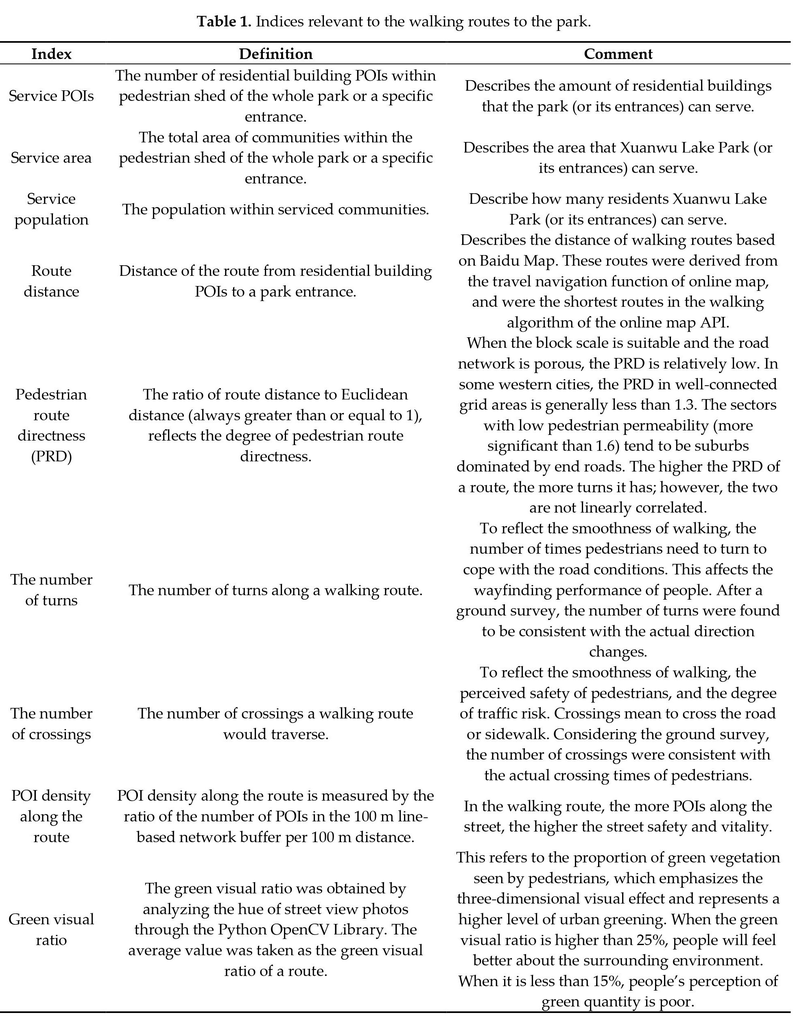

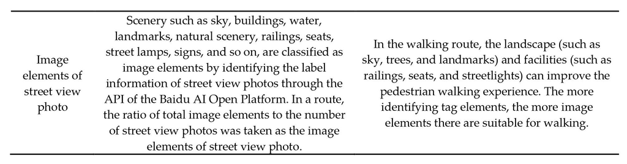

R packages used: tidyverse, dplyr, ggplot2, sf, sp.

# Expected results

The goal of this project is to provide a quantitative description of the walking route to a park using novel distance from home to the park and pedestrian environment measures. In result, I will create maps using tmap with each specific index, to find out which routes are walkable. Moreover, I will create some box plots and scatter plots to see the distribution of each index.